# Stationarity of Turkish Electricity Consumption Data

Nilüfer Çetin - IE360 - Fall 2020

25 01 2021

## Introduction

In Turkey, similar to many other parts of the world, the production and distribution of the electricity in a day is regulated via some pre-determined amounts assigned to specific distributors in a market structure. The market is governed by EPIAS and there are a lot of rules set by EPIAS that are related to the production and assignment of the electricity in the market. Moreover, EPIAS provides lots of useful data related to the market in [EPIAS Transperency Platform](https://seffaflik.epias.com.tr/transparency/tuketim/gerceklesen-tuketim/gercek-zamanli-tuketim.xhtml) for sake of transparency and to prevent cheating or uncooperative behaviors that can reduce the efficiency of the market.

An agent in the market, whether producer or distributor, faces a number of decisions each day such as how much to electricity to declare as to be produced or the maximum amount of price that can be paid in exchange of a unit of electricity for tomorrow etc. Maximizing profits calls for better and more efficient decisions. Therefore, predicting behaviors of other agents, situation of the market in near future and the possible amount of electricity that can be supplied becomes an important tool to facilitate the decision making.

One of the principal examples of these predicted data is Hourly Consumed Amount of Electricity. It can be claimed that forecasting this series is a procedure that have gained popularity among industrial organizations as well as academy in the last few years. Thus, there are wide-range of tools developed to serve the purpose. Most of the tools make use of either machine learning powered by regression or time series approaches.

The aim of this study is to transform the daily amount of electricity consumption in Turkey over 2017-2021 to stationary series by means of time series approaches or differencing via examining and testing the series by the use of proper tools and tests. To serve this aim, the time series data will repeatedly be analyzed by plotting and useful tests. By using the results derived, the possible differencing or decomposition models will be discussed and some chosen ones will be executed on the series. Then the data will be checked again for stationarity. Once a favorable and adequate enough approach is obtained, daily consumption levels between 09.01.2021-23.01.2021 will be forecasted using Moving Average and Auto Regressive Models and the errors of the forecast will be gathered to comment on the efficiency and ease of use of the approaches.

## Stationarity of the Data

Once the data is obtained from EPIAS platform and the required libraries are downloaded, the environment is ready. Since hourly data is provided, the data is aggregated to a daily level by using the daily mean. The aggregation can be carried out by sum function also, however to work with smaller and less complicated numbers mean is chosen. It should be useful to plot the daily time series,

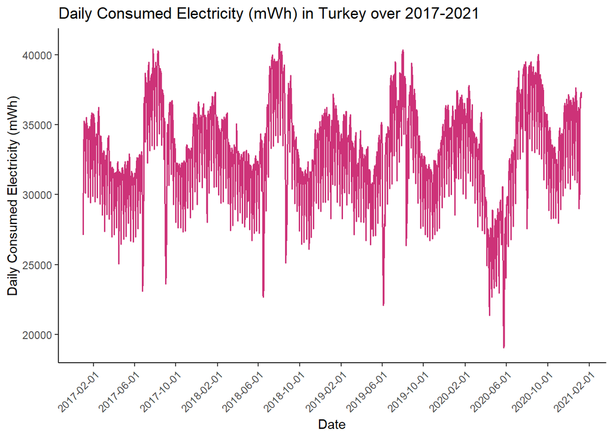

It is obvious from the plot that there is seasonality in the series, with extremely high levels in summer and lowest levels almost always seen in late springs or early autumns. The only outlier cluster in the data occurs between March 2020 and June 2020, signaling a decrease in the levels possibly related to decreased industrial activity triggered by lockdowns. Moreover, it should be stated that nearly all of the change in the levels have happened thorough the time so there are not much sudden increases or decreases in the levels. This finding may help with the use of differencing approaches that make use of lagged values. Since in the short runs the levels do not seem to change drastically, the series that can be obtained by differences between levels might contain less variance and thus be a better candidate for stationarity.

As lagged values are supposed as reliable tools that can be used in the transformation of the series, it would be appropriate to have a better understanding of auto correlation between these lagged values,

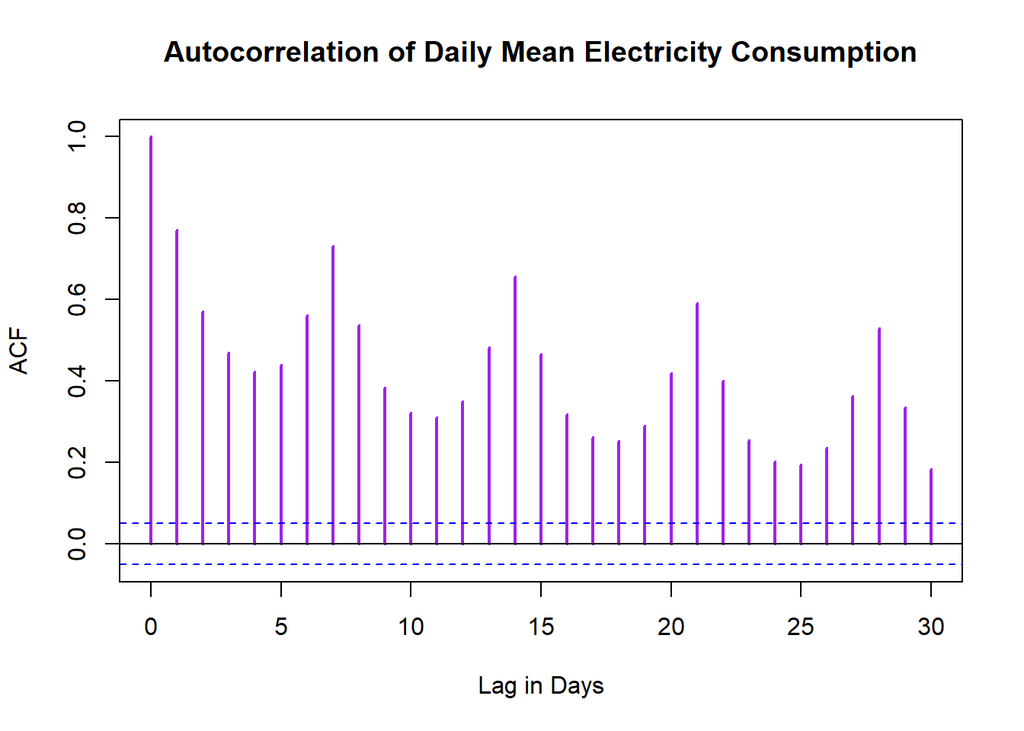

From this graph, it can be seen that profound positive autocorrelation exists even in the long runs. Furthermore, lag 7 seems to be as important as lag 1, indicating a strong weekly seasonality. It should be noted that high autocorrelation in some runs might be leading to other autocorrelations being higher too. Thus, to clarify the exact effects of seasonality a partial auto-correlation function of the series is needed,

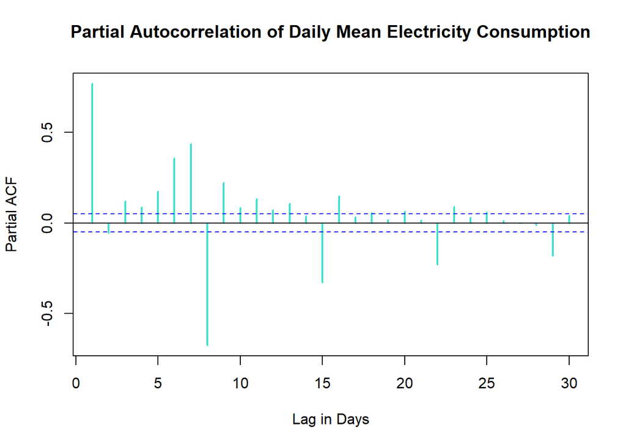

It is obvious that most of the effects are visible within a week where lag 1 and lag 7 observations have more dominance. Although there seems a strong negative correlation in lag 8, it is safer to assume that the produced amount is highly affected by continuous and similar weather conditions in lag 1 and the consumption behaviors of the same days of the week are clearly similar as indicated in lag 7. The negative correlation of lag 8 might indicate a negative relationship after the previously mentioned relationships are extracted from the data, however it can be assumed that these two lags (1 and 7) can be a good enough approximation to model the time series already and the difference might be small.

To take advantage of these results, each day can be given a base forecast using the lag 1 and lag 7 observations. In many cases, the difference between the actual observation and the forecast can be assumed as a residual since it is claimed that these lags can be actually enough to cover the future value. By taking the difference between the observation and the forecast, the distribution of the residuals might be obtained. Since being residuals these differences are expected to distribute normally with zero mean and specific variance. Hopefully, after this transformation the series might resemble a stationary distribution with some outliers that will be discussed and properly eliminated in the upcoming parts.

To obtain a forecast, adding the effect of two lags with respect to their relative autocorrelation statics have seemed to be reasonable. From the previously drawn graphs, it can be assumed that there is a 3:2 ratio between the effects of lag1 and lag7. Consequently, the forecast will be obtained by summing up %60 of the observed value of the previous day and %40 of the observed value of the last week’s same day.

Once the necessary manipulations have been done, the plot of the differenced series can be drawn,

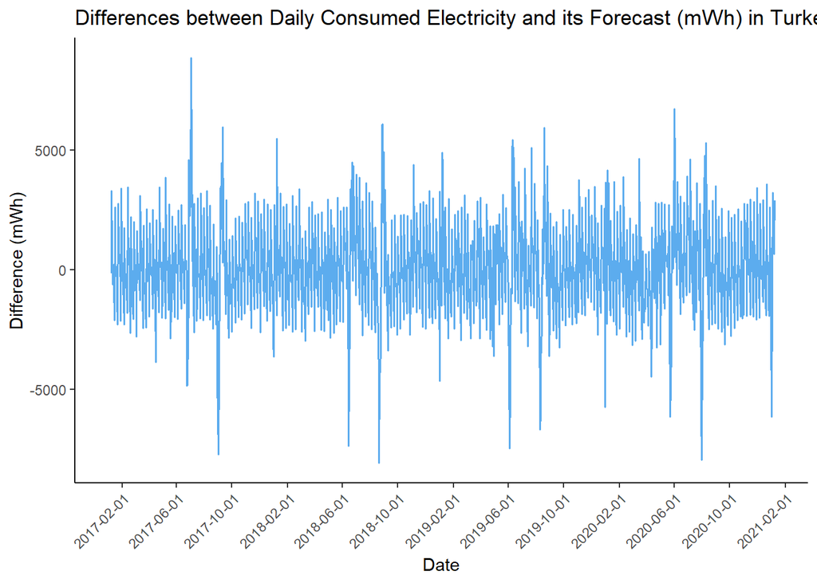

It can be commented that the series have become to resemble more as of a stationary one. The existence of the outlier values are probably related to the observations made in national and religious holidays in which consumption levels get considerably lowered, therefore effecting the differenced values of the next day and 7 days ahead. For now, once these outliers are excluded from the discussion, it can be seen that there are slight trends in some parts of the data, where the difference in the consumption levels weakly increase or decrease for a specified period of time. However, it should be noted that there also occurs observations that are not in accordance with the overall trend of the period. The existence of such behavior can prevents the data from having a strong auto correlation at small lags, thus it might facilitate the transformation to stationary.

The plot have also revealed that the variance of differences do not vary over time, another desired characteristic of stationary series. Although the plot shows satisfactory transformation, before moving on with outlier handling, some assumptions related to the stationary distribution should be checked for this particularly transformed series. Stationary data should distribute normally and to help this purpose the histogram of the differenced observations are visualized,

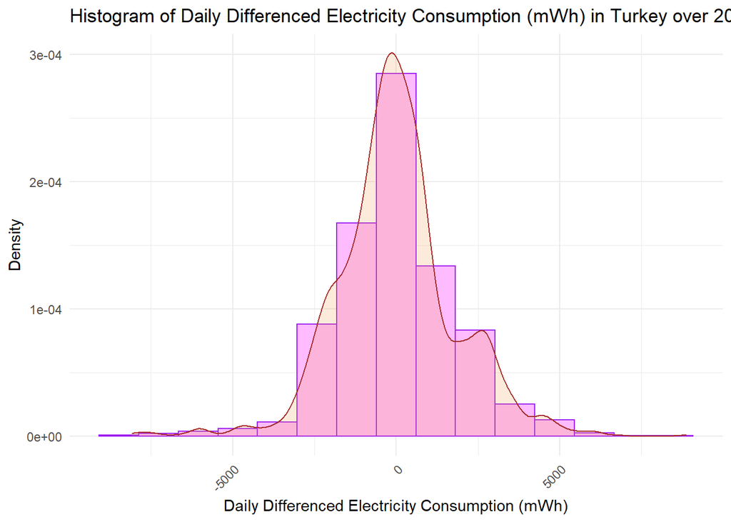

By observing the histogram, it can be claimed that the data is highly similar to a normal distribution with mean close to 0. The outlier values at the both ends of the spectrum seem to be symmetric. In fact if mean is checked,

```
## [1] 5.240197
```

It should be noted that a mean as 5, where some outliers are close to +/- 10000 can be accepted as adequate. Another assumption of the stationary series is that the observations should not be serially correlated with each other. To check this assumption,

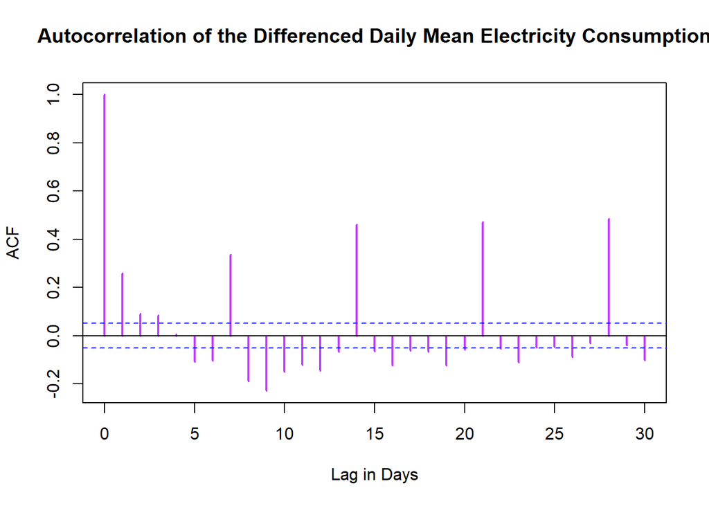

Although the series are modeled with respect to lag 1 and 7 values, the effect of weekly seasonality and day ahead values are still present in the series. To decrease the weekly seasonality, the coefficient of lag 7 in the derivation of the differenced value can be increased. However, this lead to the model being less adequate to catch the effect of previous day’s consumption. Increasing both coefficients together might probably decrease the mean to a value farther away from zero since the model takes differences by subtracting the forecast from the actual observation. It can be commented that the situation here is kind of a compromise between the two lagged values. Since the aim is not to forecast the data but actually transform it into a stationary series, further adjustment of the coefficients is not needed for this study.

Lastly, Unit Root KPSS test can be executed on the series to check if the assumption of stationarity is violated, in other words can be rejected,

```
##
## #######################
## # KPSS Unit Root Test #
## #######################
##
## Test is of type: mu with 7 lags.
##
## Value of test-statistic is: 0.0127
##
## Critical value for a significance level of:
##                 10pct  5pct 2.5pct  1pct
## critical values 0.347 0.463  0.574 0.739
```

## Outliers and Further Models

Fixing the outliers require lots of manual work. Nevertheless, it is a well-known fact that in the Turkish Electricity Market, those values occur in national holidays, religious holidays, election days, first days of a new year, days preceding or succeeding a holiday that are given as holidays or in which people tend to cancel their jobs to extend holiday duration to go to vacation and in days with mass exams. To help with the purpose, not all but some of these days are gathered and marked as special.

The next step is to provide a reasonable observation for these probably outlier days. There are actually various ways to obtain such a value however since the data is already gathered, approximating a normal consumption by using the mean of 7 days before and 7 days ahead consumption is preferred for this task.

Once these values are gathered, it should be sensible to recalculate the differenced values by using the normalized values for special days. When the series are visualized after these steps,

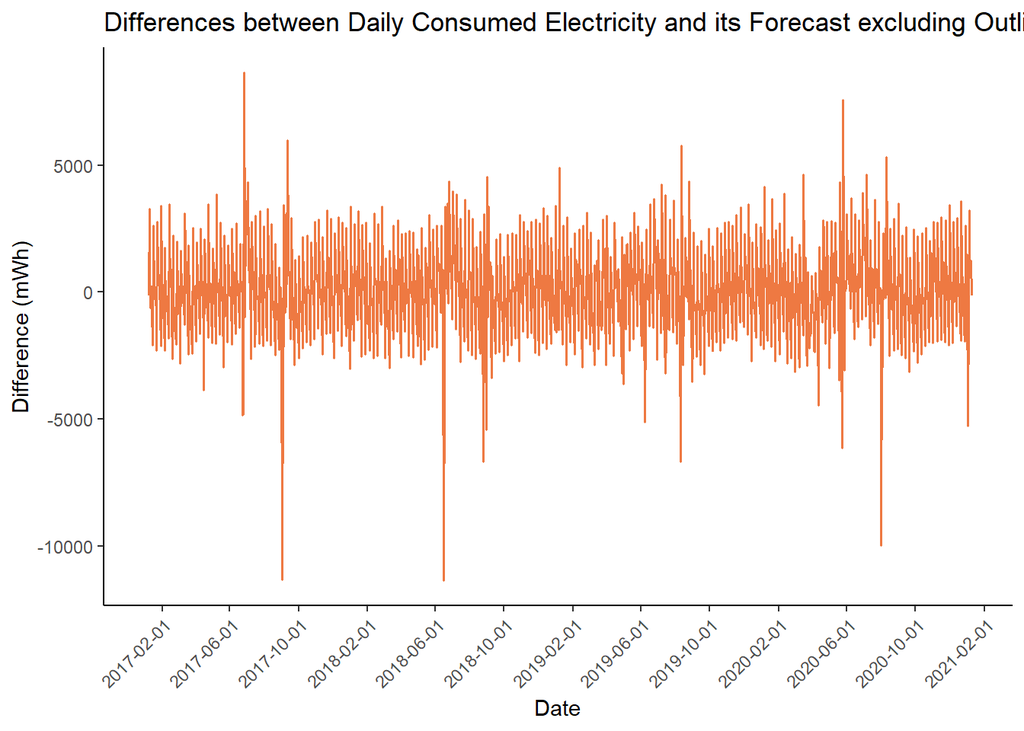

The variance within the series seem to be reduced along with reduced number of outliers. Because fixing is done manually, not all of the outlier values could be covered as can be seen from the plot. Moreover, there might be some outliers occurring in weekends that are assumed to be non-special. Once checked, the mean of the differenced series is again nearly 5. If a histogram is drawn,

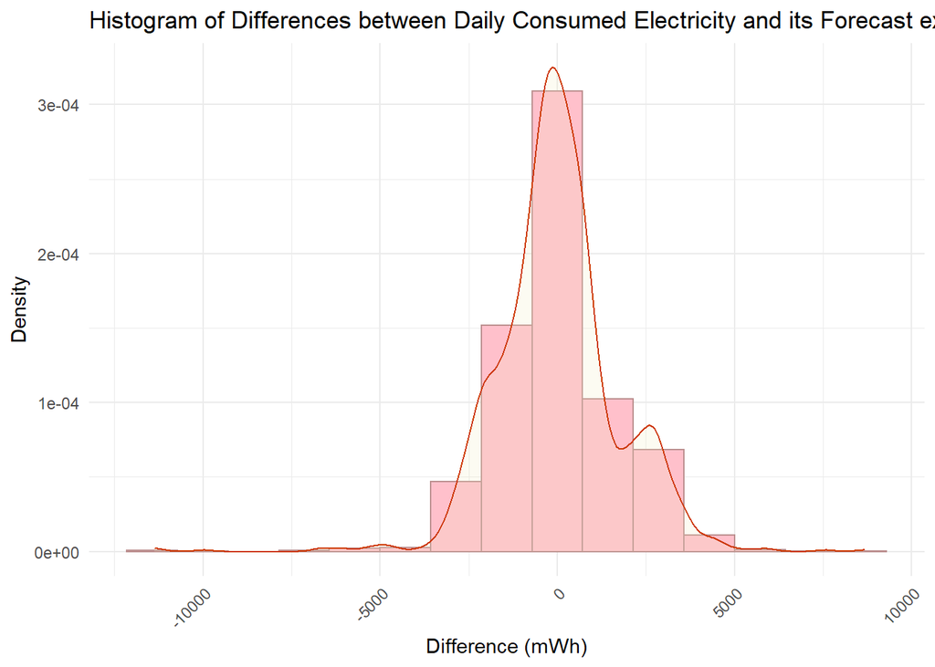

It can be seen that the distribution is resembling a normal distribution with a little negative skewness. This situation might have arisen due to mistakenly treating a day as special because it was a holiday whereas the day did not show such behavior. Nevertheless, exceptions do not break the rules. If an autocorrelation plot is obtained,

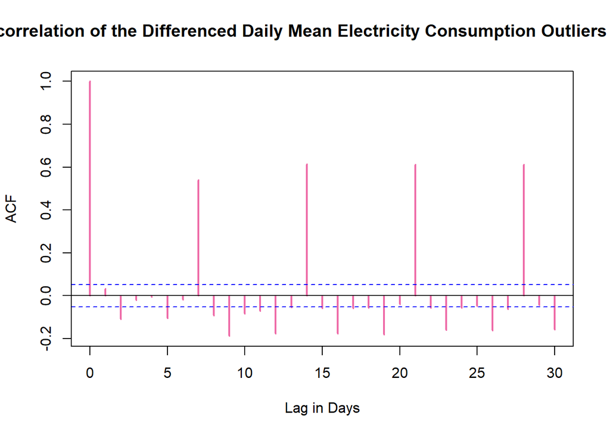

It can be seen that the serial correlation at lag 1 have been eliminated by detecting most of the outliers. This fact clearly shows that most of the serial correlation in the differenced series was due to the extreme values occurring at single day holidays that highly affect the difference between the day the holiday and it precedes. Although the model was successful in grasping this behavior, the weekly auto correlation in the series is still persistent. To eliminate such a situation, a bigger coefficient might have been given to the lag 7 observation in the first model. Nonetheless, when the Unit Root KPSS test is applied,

```
##
## #######################
## # KPSS Unit Root Test #
## #######################
##
## Test is of type: mu with 7 lags.
##
## Value of test-statistic is: 0.0242
##
## Critical value for a significance level of:
##                 10pct  5pct 2.5pct  1pct
## critical values 0.347 0.463  0.574 0.739
```

It can be seen that the test statistic is still a lot smaller than the critical boundary values, so the assumption of stationary cannot be easily rejected.

After that point the existence of a profound serial correlation at lag 7, 14 and so on might be a little hard to neglect. The variance is already much smaller and elimination of many of the outlier observations have interacted with serial correlation of lag 1 in a favorable way to decrease it. As a result, to decrease the weekly seasonality of the differenced series, a higher coefficient to lag 7 can be given, such as 0.67. Once the transformation is done that way,

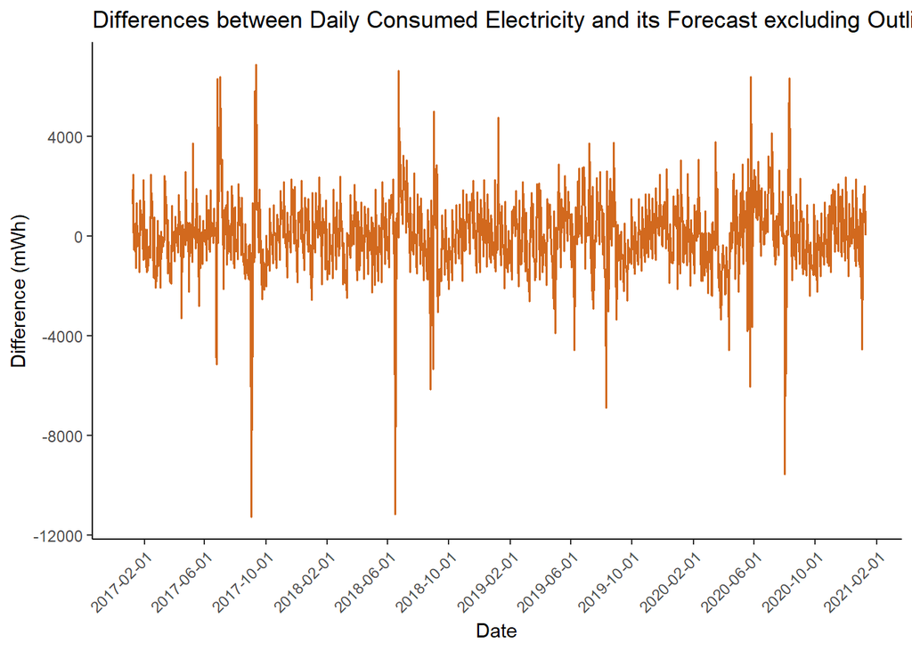

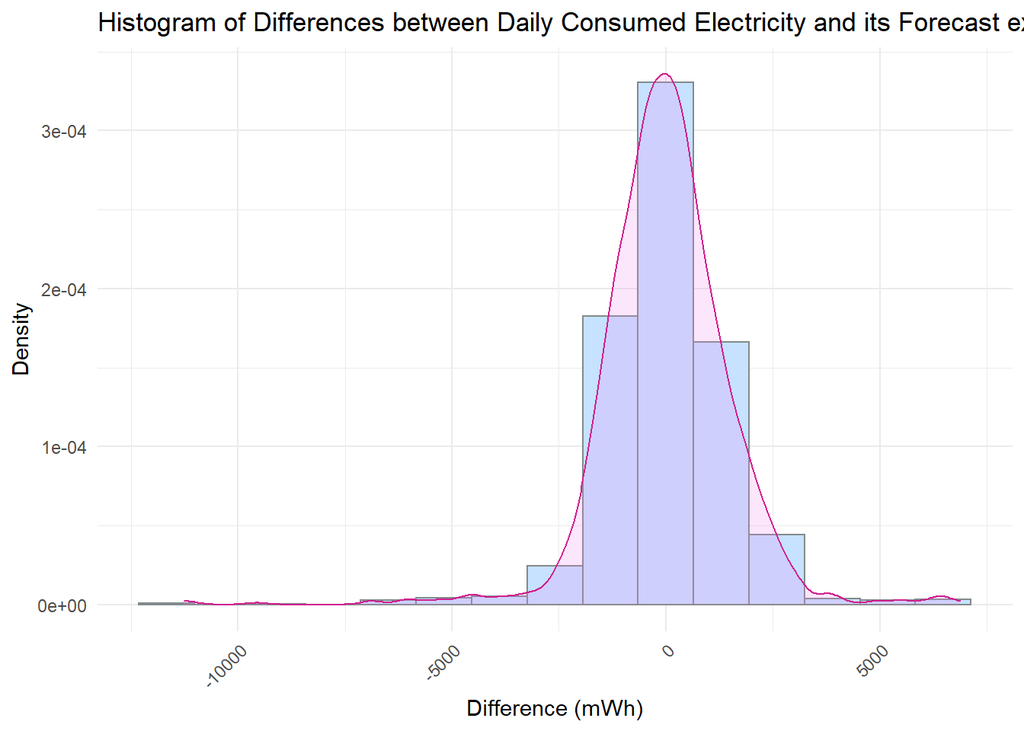

A similar histogram of the data is gathered with mean 7 that can be approximated to 0.

```
##
## #######################
## # KPSS Unit Root Test #
## #######################
##
## Test is of type: mu with 7 lags.
##
## Value of test-statistic is: 0.0252
##
## Critical value for a significance level of:
##                 10pct  5pct 2.5pct  1pct
## critical values 0.347 0.463  0.574 0.739
```

It can be stated that the statistic related to the stationarity assumption is still small, so we are not able to reject the null assumption that the data is stationary. If an auto-correlation plot is obtained,

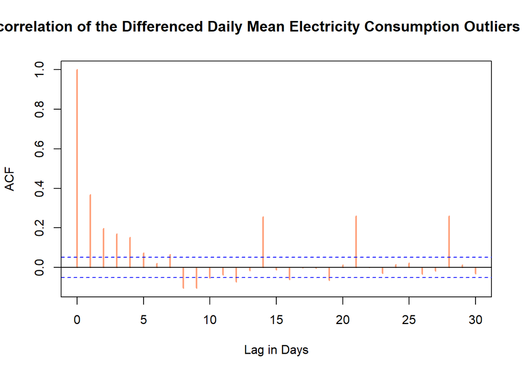

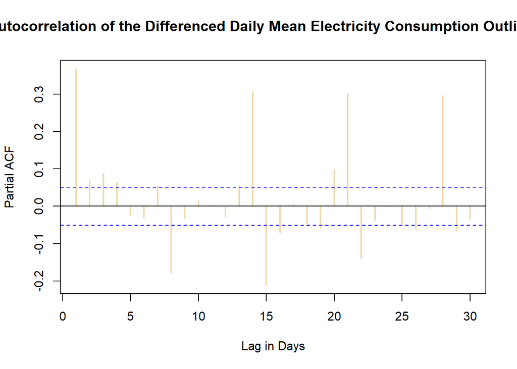

From this plot, it can be stated that on most of the lags, partial auto-correlations are negligible. Although seasonality within a week seems to be better captured by the model, the day of the week effect seems to be still persistent. This might be due to the initial assumption of the series being fundamentally auto-correlated at small lags which have led to working on these effects. It can be claimed that this approach have in general fallen short of grasping the relations at further lags as can be seen from lag 15, 22 and 29 partial auto-correlations. Nevertheless, indicated by the other statistical measures it can be accepted as enough as a basic model.

## Discussion

There are various paths that can be followed when dealing with the daily consumption of electricity data. Apart from few exogenous factors, the series is highly correlated within itself. Moreover, the series are highly seasonal within a week and a year. Coupled with auto-correlation at the day ahead behavior, it might get hard to grasp all these characteristics using a time series or differencing approach while working with the data.

Although it can be argued that using an additive or multiplicative time series approach to decompose the data might have yielded better results in some metrics, the creativity and the degree of freedom with seasonality of these approaches are rather limited. Moreover, it can be stated that the data do not show much trend in some seasons, so the power introduced by using such decomposing models might have been hindered.

Using a differencing approach have eased the process of catching the weekly seasonality and continuous day ahead effects within the series. Though it can be argued that the yearly seasonality of the series is not handled, the fact that the levels move smoothly even when there is a trend have helped since the series used differencing. It can be claimed that, at the final series the most problematic part is the handling of auto-correlation at further lags. However, use of more lagged values with better adjusted coefficients might alleviate this problem. Nevertheless, these approaches are well beyond the scope of this study.

## Use of ARIMA Models

Before any forecasting can be applied, a practical way to forecast the assumed stationary series should be found. Devising an approach to this problem, by the use of a function ARIMA models with various parameters will be tested on the model and the model with the smallest AICc statistic will be selected, indicating a better fit.

```
## Series: dailyCons1[, diff1_7_new]
## ARIMA(2,0,3) with zero mean
##
## Coefficients:
##          ar1      ar2      ma1     ma2     ma3
##       1.4349  -0.7608  -1.1499  0.4225  0.2747
## s.e.  0.0460   0.0326   0.0446  0.0426  0.0307
##
## sigma^2 estimated as 1854770:  log likelihood=-12623
## AIC=25258   AICc=25258.06   BIC=25289.72
```

Although there are several acceptable models that can be executed on the series to forecast, ARIMA(2,0,3) model is selected indicating that the differenced series can be decomposed as using 2 of the lagged values and 3 different values obtained by taking the averages of several errors made in past predictions. From the “ar1” coefficient it can be stated that the series’ reversal to the mean level of previous observations is rather slow. Moreover, regarding the coefficients, it can be commented that there occurs some kind of spikes in the series randomly and the effects of these behaviors are smoothed as the time proceeds.

## Forecasting

```
##      Point Forecast     Lo 80    Hi 80     Lo 95    Hi 95
## 1470      460.47399 -1284.870 2205.818 -2208.800 3129.748
## 1471      736.15372 -1078.685 2550.992 -2039.402 3511.709
## 1472      462.39138 -1356.627 2281.410 -2319.557 3244.340
## 1473      103.38760 -1736.738 1943.513 -2710.841 2917.616
## 1474     -203.45006 -2068.679 1661.778 -3056.071 2649.171
## 1475     -370.58286 -2249.474 1508.309 -3244.099 2502.934
## 1476     -376.94717 -2258.114 1504.220 -3253.943 2500.049
## 1477     -258.92087 -2140.499 1622.658 -3136.547 2618.705
## 1478      -84.72697 -1970.577 1801.123 -2968.886 2799.432
## 1479       75.42080 -1816.550 1967.392 -2818.099 2968.941
## 1480      172.68077 -1723.200 2068.561 -2726.818 3072.180
## 1481      190.39181 -1706.403 2087.187 -2710.506 3091.290
## 1482      141.80729 -1755.005 2038.620 -2759.117 3042.731
## 1483       58.62013 -1839.030 1956.270 -2843.585 2960.825
## 1484      -23.77807 -1922.901 1875.344 -2928.235 2880.679
```

After the differenced part of the series are predicted, using the realized consumption with lagged values to re-difference the series, actual forecasted amounts can be yielded. Before forecasting the components of the forecast can be seen for some days as,

```
##          Date daily_mean     lag1     lag7        WN
## 1: 2021-01-09   34781.56 36873.90 30276.93  460.4740
## 2: 2021-01-10   31841.90 34781.56 30023.36  736.1537
## 3: 2021-01-11   36431.46 31841.90 35548.28  462.3914
## 4: 2021-01-12   36897.99 36431.46 36723.26  103.3876
## 5: 2021-01-13   37409.87 36897.99 37182.32 -203.4501
## 6: 2021-01-14   38056.05 37409.87 37299.57 -370.5829
## 7: 2021-01-15   38170.38 38056.05 36873.90 -376.9472
## 8: 2021-01-16   35667.35 38170.38 34781.56 -258.9209
```

The realized values and predictions can be seen along with the residuals,

```
##           Date daily_mean forecast    residual
##  1: 2021-01-09   34781.56 32914.41  1867.15464
##  2: 2021-01-10   31841.90 32329.72  -487.81777
##  3: 2021-01-11   36431.46 34787.56  1643.89792
##  4: 2021-01-12   36897.99 36730.35   167.64059
##  5: 2021-01-13   37409.87 36885.04   524.82535
##  6: 2021-01-14   38056.05 36965.39  1090.66454
##  7: 2021-01-15   38170.38 36887.06  1283.31963
##  8: 2021-01-16   35667.35 35640.95    26.39472
##  9: 2021-01-17   32557.96 33019.57  -461.61308
## 10: 2021-01-18   38447.89 35228.63  3219.26001
## 11: 2021-01-19   39723.73 37582.14  2141.59402
## 12: 2021-01-20   39960.92 38363.84  1597.08607
## 13: 2021-01-21   39791.07 38826.47   964.60020
## 14: 2021-01-22   38902.97 38763.83   139.14577
## 15: 2021-01-23   35635.70 36711.32 -1075.62539
```

If a plot is visualized,

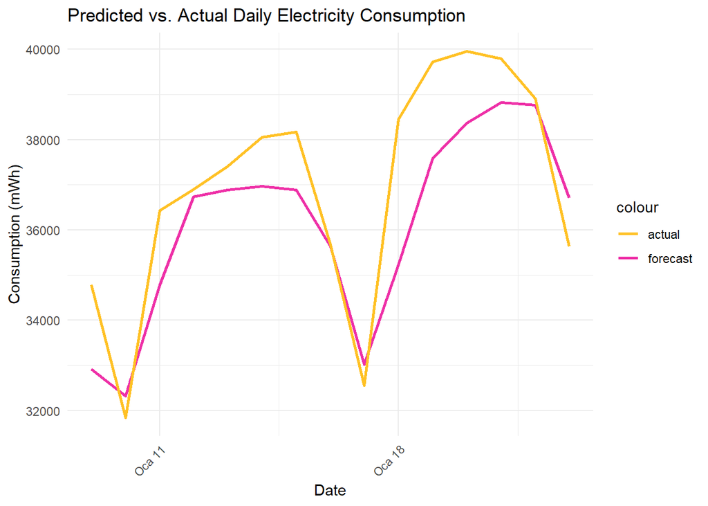

It is obvious that the model have usually underestimated the consumption levels. Nonetheless, there are considerable difference between the consumption levels of these consecutive weeks. The created model might be lacking a fast moving average component that may facilitate fine-tuning of changing levels in short runs.

Furthermore, it can be said that Mondays are the days in which the forecasts fall furthest behind of the realized consumption. In almost any week, the consumption at Sundays get considerably lower because of weekend break. Hence, when imposing the correlation with day before to the model, Mondays might have been the days that are affected in the most unfavorable way, coming after a day with not much resemblance in consumption behavior. This simple situation actually reveals a disadvantage of the time series model in forecasting. Though marking the lag 1 observations might have yielded a better model, it was not possible to adjust the effect by a different coefficient for Mondays, resulting in an over-generalization. To check other statistical measures for goodness of fit,

```
##    n     mean       sd    error      FBias       MAPE      MAD      WMAPE
## 1 15 36951.79 2500.597 1867.155 0.02280544 0.02970049 1112.709 0.03011246
```

The test statistics seem to be small. However, it should be noted that there are no clear tabulated values to compare the statistics and decide if a good fit or prediction has been obtained. The comparison might have been done with respect to one of the previously discussed models. Yet, for each model the steps involved are rather long and complicated. Consequently, to show that a clear improvement is made upon a basic algorithm, simple moving average can be used. The statistics below are obtained by forecasting each day as the last week’s same day,

```
##    n     mean       sd     error      FBias       MAPE      MAD      WMAPE
## 1 15 36951.79 2500.597 -2092.337 -0.0022339 0.05336438 1913.406 0.05178115
```

## Conclusion

In this study, the series of daily electricity consumption in Turkey was examined and tried to be stationarized by use of possible and appropriate time series approaches. The methods involved multiple differencing with respect to special lagged values. Although this choice is discussed thoroughly in the other parts, it can be said that the model developed were effective at capturing and eliminating most prominent seasonality factors.

It can be stated that use of time series or transformation operations are adequate opinions that should be considered while dealing with time series data of whose inner structure and relations to exogenous factors are rather unknown or cannot be obtained. These approaches are fast, practical and do not require much knowledge about the domain in which the series reside in.

A stationary test is assumed to be gathered in an iterative manner by use of visual and statistical analysis that are carried out via drawing several plots and executing tests such as Unit Root KPSS. By introducing differencing at lag 1 and lag 7, the effects of previous day and day of the week were eliminated from the series. However, these eliminations were limited to some extent by one each other and introducing a higher degree of coefficient to one of the lags resulted in less weight given to another. Hence, the resultant differenced series suffered from some degree of auto-correlation. Moreover, the only effects captured were the ones in the short run. It can be stated that with better adjustment of parameters and introducing further transformations that can be enabled by more detailed examination of the serial correlation within observations, a model in which the rejection of stationarity assumption can be even harder might have been obtained. Nevertheless, the presented transformation can be accepted as an adequate one that uses power of auto-correlation in this scope of study.

Once the differenced series are obtained, by utilizing ARIMA models and inversing the transformations daily forecasts for the period of 9-23 January are created. As proven by the performance measures shown in the previous parts, it can be claimed that the performance of the model is improved with respect to simple moving average models that are accepted as the most basic approach in forecasting or gathering information from time series. However, as discussed in the previous parts, most of the forecasts fell behind of the actual observed amount, indicating lack of speed of the model in tracing the level. Another finding was that the differenced models might involve over-generalizations that can impair performance for some specific periods in the exchange of better prediction for more of them.

It can be said that the time series approaches are practical and useful in most cases where the inner works of the data are not known or highly complicated to the researcher. Nevertheless, these tools are far from yielding a comprehensive and detailed model on the prediction side, leading to errors or unexplained behavior that tends to remain while forecasting.

## References

[EPIAS Transperency Web Site](https://seffaflik.epias.com.tr/transparency/tuketim/gerceklesen-tuketim/gercek-zamanli-tuketim.xhtml) • [R data.table Cheat Sheet](https://s3.amazonaws.com/assets.datacamp.com/blog_assets/datatable_Cheat_Sheet_R.pdf) • [Colors](http://sape.inf.usi.ch/quick-reference/ggplot2/colour) • [Other Questions](https://stackoverflow.com/)

## Appendices

[Here](https://bu-ie-360.github.io/fall20-nilufercetin/files/HMW4.Rmd) the RMD File including the code chunks can be found.